# In Class Exercise Lecture 3

### imports

```r
library(tidyverse)
```

```r
library(ggplot2)
library(bayesrules)
library(HDInterval)
library(palmerpenguins)
library(dplyr)
```

Exercise / Example 1: MTCars and posterior estimation using intervals

```r
cars <- mtcars
y <- cars$mpg
n <- length(y)
y_bar <- mean(y)
head(cars)
```

```
##                    mpg cyl disp  hp drat    wt  qsec vs am gear carb
## Mazda RX4         21.0   6  160 110 3.90 2.620 16.46  0  1    4    4
## Mazda RX4 Wag     21.0   6  160 110 3.90 2.875 17.02  0  1    4    4
## Datsun 710        22.8   4  108  93 3.85 2.320 18.61  1  1    4    1
## Hornet 4 Drive    21.4   6  258 110 3.08 3.215 19.44  1  0    3    1
## Hornet Sportabout 18.7   8  360 175 3.15 3.440 17.02  0  0    3    2
## Valiant           18.1   6  225 105 2.76 3.460 20.22  1  0    3    1
```

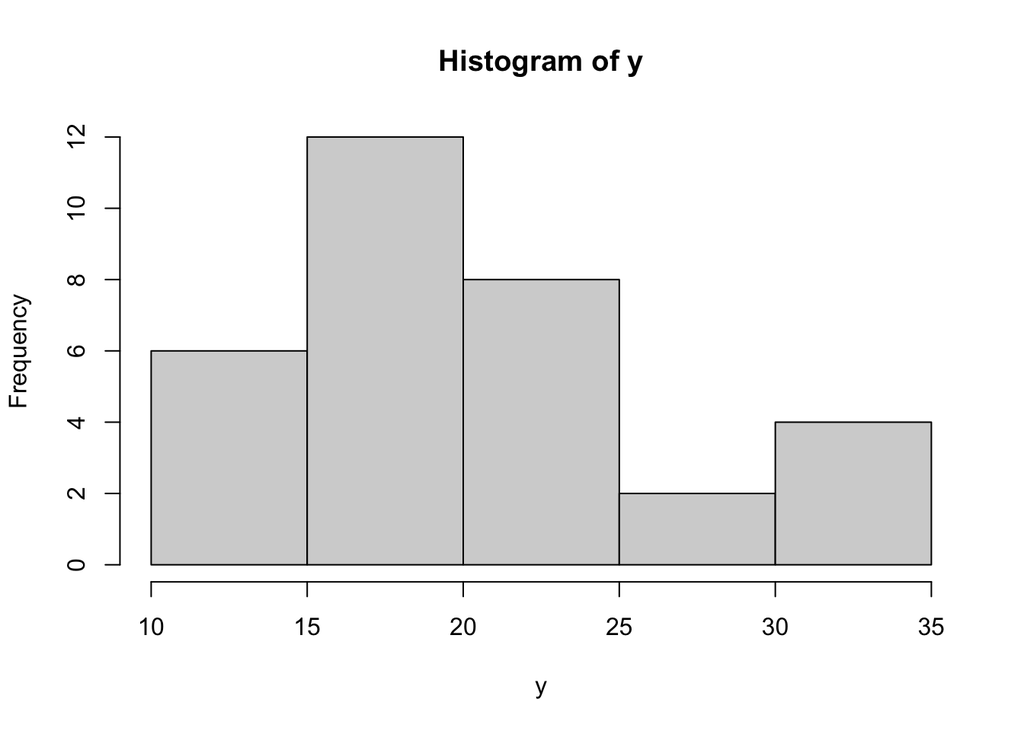

```r
hist(y)
```

## Task 1: Analyze mean mpg

- Assume normal prior on mu with prior mean $m_\mu = 22$ and prior variance $s_{\mu}^2 = 25$
- Likelihood: $y \sim N(\mu, \sigma^2)$ with known variance $\sigma^2 = 9$

expected: (m_star, s2_star) = 20.11187, 0.2781211

```r
m_mu <- 22
s2_mu <- 25
sigma2 <- 9

s2_star <- 1/((1/s2_mu) + (n/sigma2))
m_star <- ((1/s2_mu) / (n/sigma2 + 1/s2_mu))*m_mu +
  ((n/sigma2)/(n/sigma2 + 1/s2_mu))*y_bar

m_star
```

```
## [1] 20.11187
```

```r
s2_star
```

```
## [1] 0.2781211
```

We first generate the central posterior credible interval of 95%

```r
#generate posterior sample then
posterior <- rnorm(10000, m_star, sqrt(s2_star))


#analytical
lo <- qnorm(0.025, mean = m_star, sd = sqrt(s2_star))
hi <- qnorm(0.975, mean = m_star, sd = sqrt(s2_star))

cat("95% credible interval generated by analytical : [", lo, ", ", hi, "]\n")
```

```
## 95% credible interval generated by analytical : [ 19.07824 ,  21.1455 ]
```

```r
#sample
print("The posterior credible interval generated by sampling the posterior distribution")
```

```
## [1] "The posterior credible interval generated by sampling the posterior distribution"
```

```r
quantile(posterior, c(0.025, 0.975))
```

```
##     2.5%    97.5%
## 19.03574 21.14500
```

We can generate another 95% credible interval, but just not the central one

```r
print("analytical 95% credible interval from 0.01 to 0.96")
```

```
## [1] "analytical 95% credible interval from 0.01 to 0.96"
```

```r
qnorm(c(0.01, 0.96), mean = m_star, sd = sqrt(s2_star))
```

```
## [1] 18.88502 21.03513
```

```r
print("sample 95% credible interval from 0.01 to 0.96")
```

```
## [1] "sample 95% credible interval from 0.01 to 0.96"
```

```r
quantile(posterior, c(0.01, 0.96))
```

```
##      1%     96%
## 18.8335 21.0368
```

Now compute the HDPI for the same posterior distribution (the expectation is that it will be similar if not the same as central credible interval)

```r
hpdi <- hdi(posterior, credMass = 0.95)
print("HDPI")
```

```
## [1] "HDPI"
```

```r
hpdi
```

```
##    lower    upper
## 19.02288 21.12885
## attr(,"credMass")
## [1] 0.95
```

## Task 2: Bayesian Hypothesis Testing

H0: mu <= 20 H1: mu > 20

```r
ph1 <- mean(posterior > 20)

cat("Posterior Mean:", m_star, "\n")
```

```
## Posterior Mean: 20.11187
```

```r
cat("P(mu > 20):", ph1, "\n")
```

```
## P(mu > 20): 0.5835
```

## Task 3: Posterior Predictive

So the posterior predictive distribution gives us a way to validate our models and also predict the correct distribution from which our data comes from. For this task, we will be predicting bill lengths of penguins

The assumptions:

1. normal normal
2. prior: mean = 50, s2_mu = 100
3. sigma2 = 9

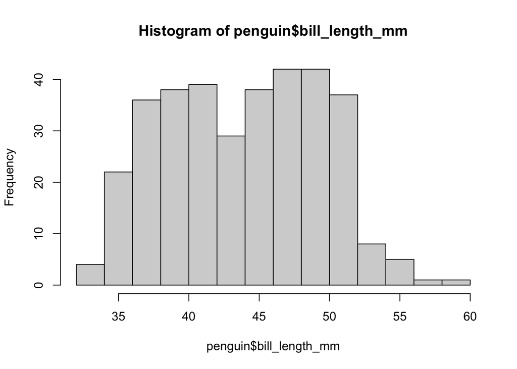

```r
penguin <- penguins |>
  filter(!is.na(bill_length_mm))

hist(penguin$bill_length_mm)
```

```r
head(penguin)
```

```
## # A tibble: 6 × 8
##   species island    bill_length_mm bill_depth_mm flipper_length_mm body_mass_g
##   <fct>   <fct>              <dbl>         <dbl>             <int>       <int>
## 1 Adelie  Torgersen           39.1          18.7               181        3750
## 2 Adelie  Torgersen           39.5          17.4               186        3800
## 3 Adelie  Torgersen           40.3          18                 195        3250
## 4 Adelie  Torgersen           36.7          19.3               193        3450
## 5 Adelie  Torgersen           39.3          20.6               190        3650
## 6 Adelie  Torgersen           38.9          17.8               181        3625
## # ℹ 2 more variables: sex <fct>, year <int>
```

Expected (m_star, s2_star) = (43.92353, 0.02630887)

```r
y <- penguin$bill_length_mm
y_bar <- mean(y)
n <- nrow(penguin)

m_mu <- 50
s2_mu <- 100
sigma2 <- 9

s2_star <- 1/((1/s2_mu) + (n/sigma2))
m_star <- ((1/s2_mu) / (n/sigma2 + 1/s2_mu))*m_mu +
  ((n/sigma2)/(n/sigma2 + 1/s2_mu))*y_bar

m_star
```

```
## [1] 43.92353
```

```r
s2_star
```

```
## [1] 0.02630887
```

We plot the posterior distribution and notice that the mean is roughly arouind 43.9

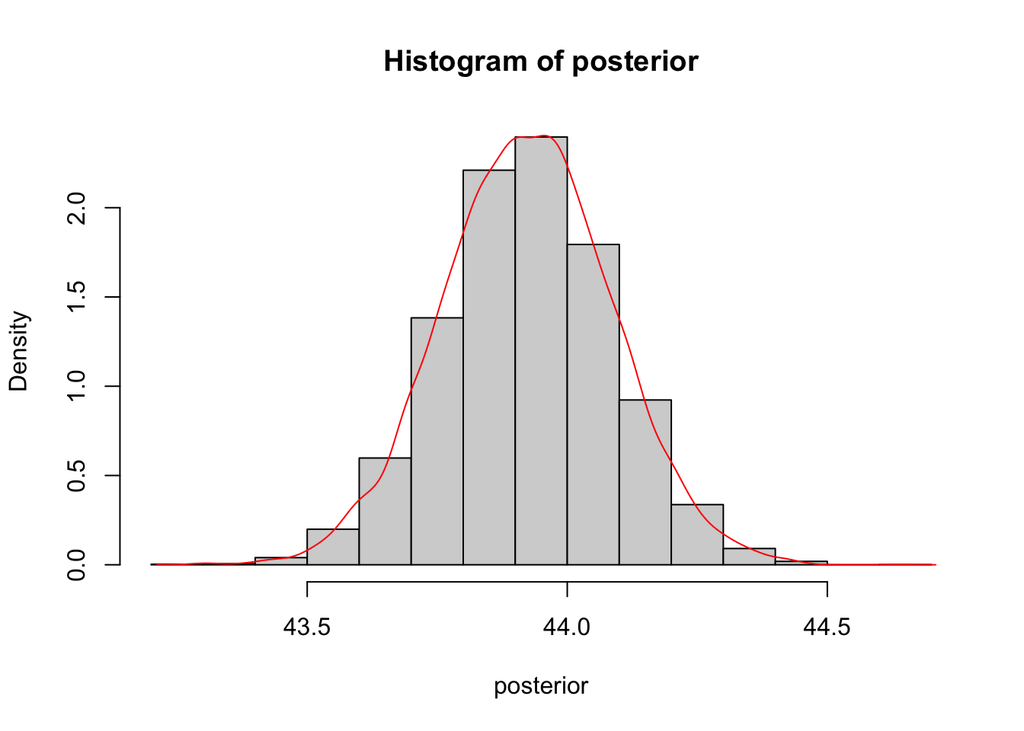

```r
posterior <- rnorm(10000, mean=m_star, sd = sqrt(s2_star))
hist(posterior, freq = FALSE)
lines(density(posterior), col = 'red')
```

We construct the posterior predictive distribution from samples of the posterior (so all realizations)

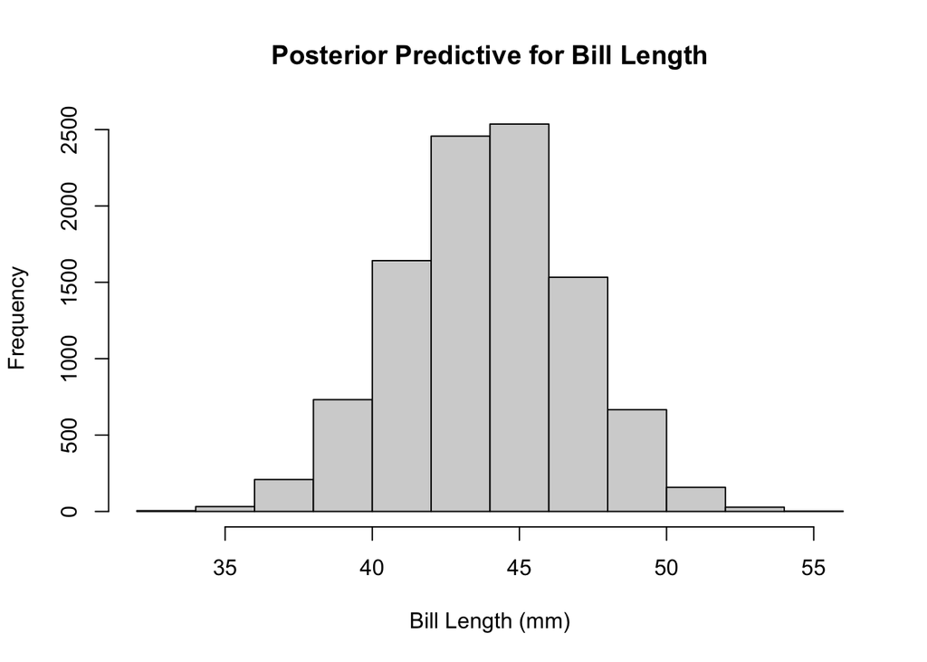

```r
posterior_predictive <- rnorm(10000, mean = posterior, sd = sqrt(sigma2))
hist(posterior_predictive, main = "Posterior Predictive for Bill Length", xlab = "Bill Length (mm)")
```

Now in closed form:

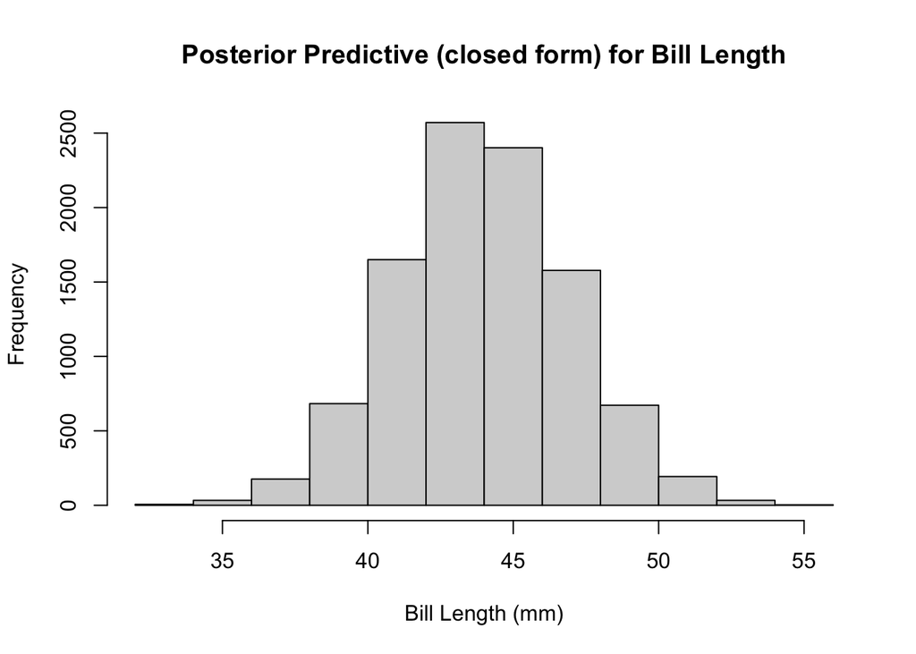

```r
y_pred <- rnorm(10000, mean=m_star, sd = sqrt(s2_star + sigma2))
hist(y_pred, main = "Posterior Predictive (closed form) for Bill Length", xlab = "Bill Length (mm)")
```